# Sales Transactions Analysis

- Dataset: `CS.xlsx`

The dataset contains historical records of coffee shop sales transactions. Each row represents a transaction performed and the variables are as follows:

- `transaction_id`: Unique identifier for each transaction
- `transaction_date`: Date of the transaction
- `transaction_time`: Time of the transaction
- `transaction_qty`: Quantity of product sold in the transaction
- `store_id`: Identifier for the store location
- `store_location`: Location of the store
- `product_id`: Unique identifier for product
- `unit_price`: Unit price of the product
- `product_category`: Category of the product
- `product_type`: Type of product within the category
- `product_detail`: Name of the product
- `revenue`: Revenue from the transaction
- `Month`: Month (Numerical) of the transaction
- `Month.t`: Month of the transaction
- `Weekday`: Day (Numerical) of week of the transaction
- `Weekday.t`: Day of week of the transaction
- `Hour`: Hour of the day of the transaction

### Preparation

```r
#install.packages - only need to run this code once to install the package
# load required packages
# library("xxxx")
library("dplyr")
library("tidyverse") #need to call the library before you use the package
library("rpivotTable")
library("knitr")
library("psych")
library("RColorBrewer")
library("readxl")
```

```r
# import dataset into RStudio
vCS <- read_excel("CS.xlsx",
                 col_types = c("numeric", "date", "date",
                               "numeric", "numeric", "text", "numeric",
                               "numeric", "text", "text", "text",
                               "numeric", "numeric", "text", "numeric", "text", "numeric"))
```

### Data Inspection

Checking for missing values in the data.

```
##   transaction_id transaction_date transaction_time  transaction_qty
##                0                0                0                1
##         store_id   store_location       product_id       unit_price
##                0                0                0                0
## product_category     product_type   product_detail          revenue
##                0                0                0                7
##            Month          Month-t          Weekday        Weekday-t
##                0                0                0                0
##             Hour
##                0
```

```
## [1] 149110
```

```
## [1] 149450
```

```
## [1] 149110 149111 149112 149113 149114 149115 149116
```

```
## # A tibble: 7 × 1
##   transaction_id
##            <dbl>
## 1         149450
## 2         149451
## 3         149452
## 4         149453
## 5         149454
## 6         149455
## 7         149456
```

Transaction_qty has 1 missing value, and the corresponding transaction id is 149450. Revenue has 7 missing values, and the corresponding transaction ids are 149450, 149451, 149452, 149453, 149454, 149455, 149456.

### Transactions Dashboard

Store managers would like to know when, where and for what products transactions take place.

Number of Transactions for Each Store Location

| store_location | n |
| --- | --- |
| Astoria | 50599 |
| Hell’s Kitchen | 50735 |
| Lower Manhattan | 47782 |

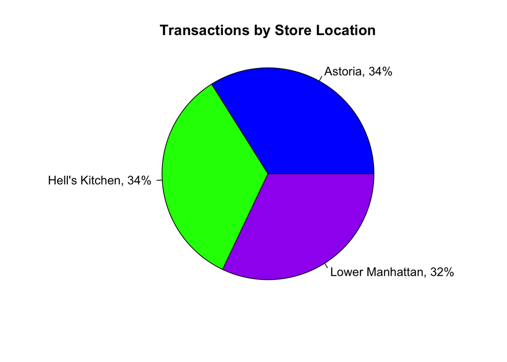

Number of Transactions by Product Type

| product_type | n |
| --- | --- |
| Barista Espresso | 16403 |
| Biscotti | 5711 |
| Black tea | 303 |
| Brewed Black tea | 11350 |
| Brewed Chai tea | 17183 |
| Brewed Green tea | 5671 |
| Brewed herbal tea | 11245 |
| Chai tea | 443 |
| Clothing | 221 |
| Drinking Chocolate | 266 |
| Drip coffee | 8477 |
| Espresso Beans | 319 |
| Gourmet Beans | 366 |
| Gourmet brewed coffee | 16912 |
| Green beans | 134 |
| Green tea | 159 |
| Herbal tea | 305 |
| Hot chocolate | 11468 |
| House blend Beans | 183 |
| Housewares | 526 |
| Organic Beans | 415 |
| Organic Chocolate | 221 |
| Organic brewed coffee | 8489 |
| Pastry | 6912 |
| Premium Beans | 336 |
| Premium brewed coffee | 8135 |
| Regular syrup | 4979 |
| Scone | 10173 |
| Sugar free syrup | 1811 |

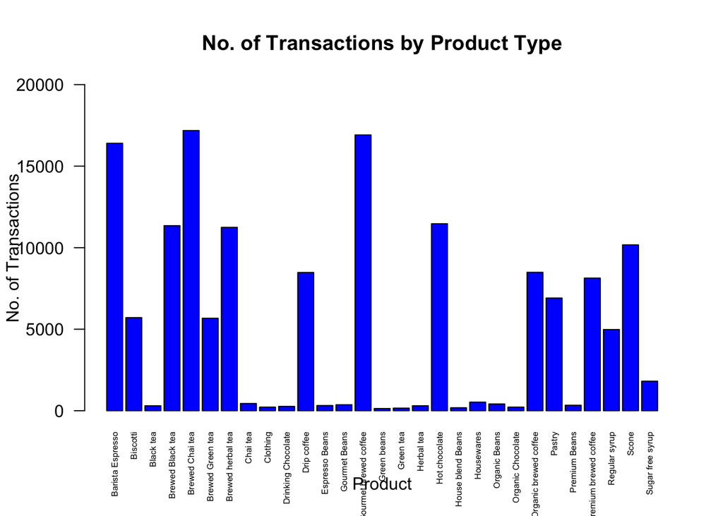

```
## [1] FALSE
```

```
## [1] FALSE
```

```
## [1] FALSE
```

```
## [1] FALSE
```

Frequency of Transactions by Month

| Month-t | n |
| --- | --- |
| Jan | 17314 |
| Feb | 16359 |
| Mar | 21229 |
| Apr | 25335 |
| May | 33527 |
| Jun | 35352 |

Frequency of Transactions by Weekdays

| Weekday-t | n |
| --- | --- |
| Sun | 21096 |
| Mon | 21643 |
| Tue | 21202 |
| Wed | 21310 |
| Thu | 21654 |
| Fri | 21701 |
| Sat | 20510 |

Frequency of Transactions by Hour

| Hour | n |
| --- | --- |
| 6 | 4594 |
| 7 | 13428 |
| 8 | 17654 |
| 9 | 17764 |
| 10 | 18545 |
| 11 | 9766 |
| 12 | 8708 |
| 13 | 8714 |
| 14 | 8933 |
| 15 | 8979 |
| 16 | 9093 |
| 17 | 8745 |
| 18 | 7498 |
| 19 | 6092 |
| 20 | 603 |

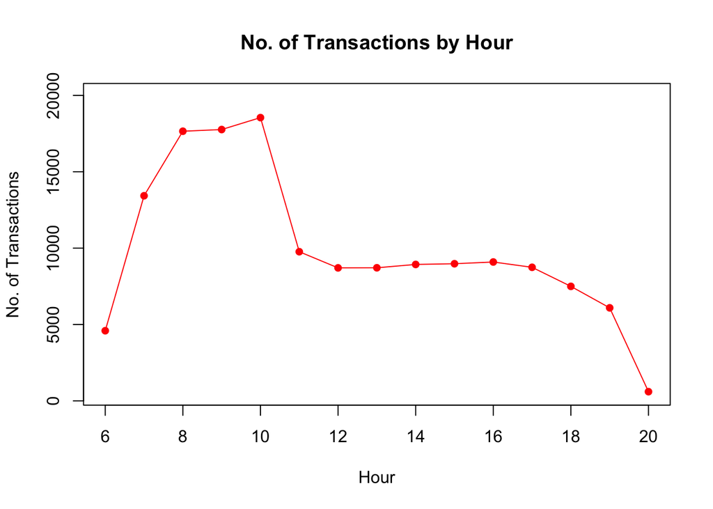

Based on the results, it can be seen that Hell’s Kitchen and Astoria carry out roughly the same number of transactions, with Lower Manhattan having the least transactions. Brewed Chai Tea is the most sold product and Green Beans is the least sold product. Most transactions occur in June and the least number of transactions occurred in February. Transactions are roughly the same across the days of the week. Most transactions occur from 7am-11am.

### Transactions Dashboard II

Store managers would like to know the frequency of transactions by store locations and month.

Contingency Table for Store Location and Month

| store_location | 1 | 2 | 3 | 4 | 5 | 6 |
| --- | --- | --- | --- | --- | --- | --- |
| Astoria | 5913 | 5490 | 7180 | 8556 | 11475 | 11985 |
| Hell’s Kitchen | 5868 | 5606 | 7267 | 8629 | 11294 | 12071 |
| Lower Manhattan | 5533 | 5263 | 6782 | 8150 | 10758 | 11296 |

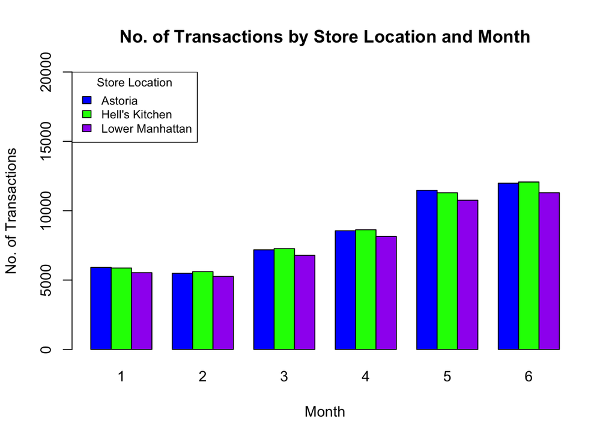

Lower Manhattan consistently has the least transactions. Month 2 (Feb) has the least transactions while month 6 (June) has the most transactions.

### Pareto Analysis Dashboard

Conduct Pareto Analysis to check if a large proportion of transactions come from a small number of product types.

```
## [1] 0.3448276
```

34.48276% of product types make up at least 80% of transactions

### Revenue Analysis Dashboard

Analysing the revenue data by the store locations

Descriptive Statistics for Revenue

| vars | n | mean | sd | min | max | skew | kurtosis |
| --- | --- | --- | --- | --- | --- | --- | --- |
| Revenue | 149109 | 4.69 | 4.23 | 0.8 | 360 | 41.74 | 3359.5 |

Descriptive Statistics for Revenue by Store Location

| store_location | n | mean | total |
| --- | --- | --- | --- |
| Astoria | 50599 | 4.59 | 232243.9 |
| Hell’s Kitchen | 50729 | 4.66 | 236483.8 |
| Lower Manhattan | 47781 | 4.81 | 230052.2 |

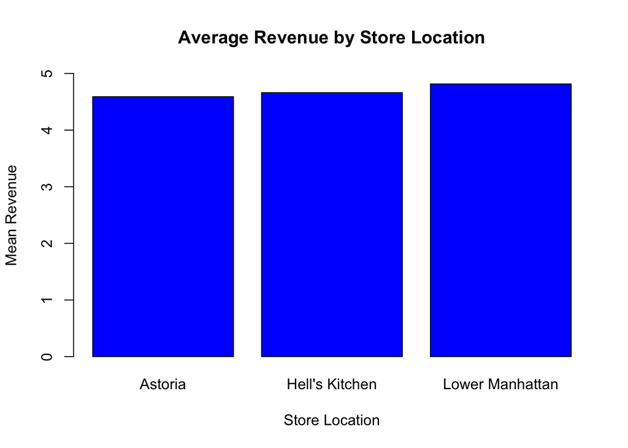

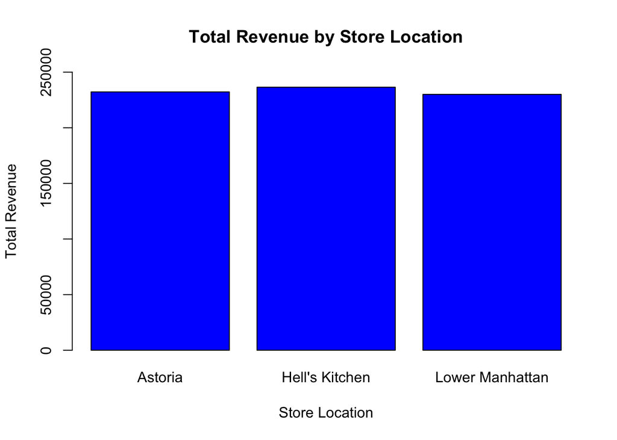

Given that skew = 41.74, there is high-degree of skewness for right-skewed data. Additionally, a kurtosis value of 3359.5 indicates leptokurtic distribution, meaning there are longer tails due to extreme outliers. Thus, data is not normally distributed. The average revenue for Lower Manhattan is the highest, followed by Hell’s Kitchen then Astoria. The total revenue for Hell’s Kitchen is the most as seen in the bar plot, followed by Astoria then Lower Manhattan.

### Correlation Analysis Dashboard

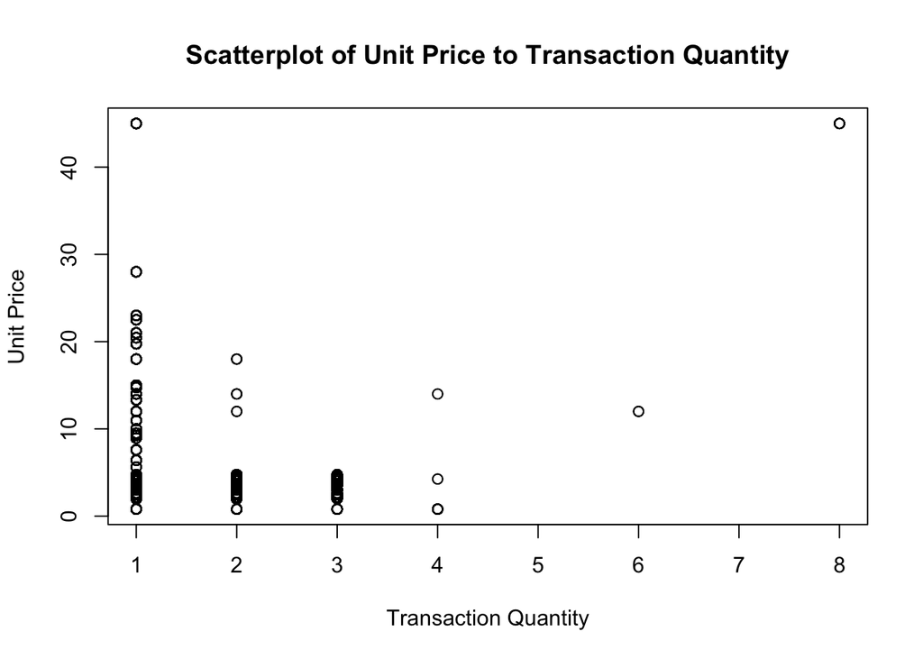

```
##
##  Pearson's product-moment correlation
##
## data:  CS2$transaction_qty and CS2$unit_price
## t = -48.072, df = 149107, p-value < 2.2e-16
## alternative hypothesis: true correlation is not equal to 0
## 95 percent confidence interval:
##  -0.1285334 -0.1185369
## sample estimates:
##        cor
## -0.1235382
```

```
## Call:corr.test(x = CS2$transaction_qty, y = CS2$unit_price)
## Correlation matrix
## [1] -0.12
## Sample Size
## [1] 149109
## These are the unadjusted probability values.
##   The probability values  adjusted for multiple tests are in the p.adj object.
## [1] 0
##
##  To see confidence intervals of the correlations, print with the short=FALSE option
```